# Final Project

Nash Lawrence

4/20/22

## Install and load the packages needed for this assignment

## 1.) Give description of your dataset including a description of the variables

My dataset is a CSV file I made back in March to analyze all 68 teams in the NCAA Men’s Basketball Tournament

1. team_id: each teams unique numeric code numbered 1-68
2. team_name: the name of each school, some abbreviated (Ex-“UNC” for North Carolina University)
3. team_conference: the abbreviation of the conference the school is in (Ex- “ACC” or “Pac 12”)
4. p6_conference: a boolean to see if the school is in one of the main 6 conferences(ACC/Big East/Big Ten/Big 12/Pac 12/SEC). Y= Yes, N= No
5. conference_champ: a boolean to see if the school won their conference tournament championship. Y=Yes, N=No
6. tourney_seed: the number seed the school is in their respective region. Integer 1-16, 1=Best rank, 16=Worst rank
7. tourney_region: the regional bracket each school is in(West/South/East/Midwest)
8. opponent_name: the name of the school that each team is playing in their first tournament game
9. total_wins: the total amount of wins the school had on the season overall
10. total_loss: the total amount of losses the school had on the season overall
11. conference_wins: the total amount of wins the school had against teams in their conference
12. conference_loss: the total amount of losses the school had against teams in their conference
13. home_wins: the total amount of wins the school had in home games
14. home_loss: the total amount of losses the school had in home games
15. road/n_wins: the total amount of wins the school had in away or neutral site games
16. road/n_loss: the total amount of losses the school had in away or neutral site games
17. SOS: the schools ranking in Strength of Schedule (Rank 1-354)
18. SOR: the schools ranking in the Strength of Record metric which measures how impressive a teams record is based on opponents
19. KP: the schools ranking in KenPom, a system that ranks teams based on a number of metrics and statistics
20. NET: the schools ranking in the NCAA Evaluation Tool, a system that ranks teams based on metrics and statistics
21. off_efficiencyRank: the schools ranking in offensive efficiency, which is points scored per possession
22. def_efficiencyRank: the schools ranking in defensive efficiency, which is points allowed per possession
23. pace_rank: the schools ranking in possessions per game to measure which teams play at a fast/slow pace
24. team_ppg: the schools points per game average
25. fg_percentage: the schools overall shooting percentage
26. three_percentage: the schools overall shooting percentage on three point shots
27. ft_percentage: the schools overall shooting percentage on free throw shots
28. 3PA_perGame: the schools average for three point shots attempted each game
29. assists_perGame: the schools assists per game average
30. rebounds_perGame: the schools rebounds per game average
31. offReb_perGame: the schools offensive rebounds per game average
32. steals_pg: the schools steals per game average
33. blocks_pg: the schools blocks per game average
34. turnovers_pg: the schools turnovers per game average (fewer = better)

## 2.) Load your dataset and save it to a RTibble/Pandas dataframe object and display the first 5 rows

```r
url <- "C:/Users/stewi/BUS440/Personal Projects/teamData.csv"
teams <- read_csv(url)
teams %>% head()
```

| team_id | team_name | team_conference | p6_conference | conference_champ | tourney_seed | tourney_region | opponent_name | total_wins | total_loss | conference_wins | conference_loss | home_wins | home_loss | road/n_wins | road/n_loss | SOS | SOR | KP | NET | off_efficiencyRank | def_efficiencyRank | pace_rank | team_ppg | fg_percentage | three_percentage | ft_percentage | 3PA_perGame | assists_perGame | rebounds_perGame | … |
| --- | --- | --- | --- | --- | --- | --- | --- | --- | --- | --- | --- | --- | --- | --- | --- | --- | --- | --- | --- | --- | --- | --- | --- | --- | --- | --- | --- | --- | --- | --- |
| 1 | Gonzaga | WCC | N | Y | 1 | West | Georgia State | 26 | 3 | 13 | 1 | 16 | 0 | 10 | 3 | 59 | 7 | 1 | 1 | 1 | 7 | 11 | 87.8 | 52.7 | 37.9 | 73.0 | 22.1 | 18.2 | 41.5 | … |
| 2 | Duke | ACC | Y | N | 2 | West | Cal State Fullerton | 28 | 6 | 16 | 4 | 15 | 3 | 13 | 3 | 67 | 11 | 12 | 13 | 7 | 44 | 186 | 80.2 | 48.9 | 36.8 | 72.9 | 22.2 | 16.9 | 38.3 | … |
| 3 | Texas Tech | Big 12 | Y | N | 3 | West | Montana State | 25 | 9 | 12 | 6 | 18 | 0 | 7 | 9 | 12 | 12 | 9 | 9 | 65 | 1 | 194 | 71.7 | 47.0 | 31.4 | 69.9 | 19.0 | 13.6 | 36.5 | … |
| 4 | Arkansas | SEC | Y | N | 4 | West | Vermont | 25 | 8 | 13 | 5 | 17 | 2 | 8 | 6 | 46 | 16 | 20 | 20 | 40 | 16 | 28 | 76.9 | 44.0 | 30.7 | 75.3 | 20.8 | 14.1 | 38.2 | … |
| 5 | Uconn | Big East | Y | N | 5 | West | New Mexico State | 23 | 9 | 13 | 6 | 14 | 2 | 9 | 7 | 40 | 22 | 18 | 16 | 21 | 35 | 174 | 75.2 | 43.6 | 35.3 | 75.0 | 21.1 | 14.0 | 40.9 | … |
| 6 | Alabama | SEC | Y | N | 6 | West | TBD | 19 | 13 | 9 | 9 | 13 | 3 | 6 | 10 | 1 | 29 | 25 | 30 | 14 | 94 | 10 | 80.0 | 44.1 | 30.8 | 73.0 | 30.1 | 14.6 | 40.0 | … |

## 3.) Identify the numerical and categorical columns you will investigate. Write a paragraph describing why you chose them.

The categorical variables I am going to use are: team_name, team_conference, p6_conference, tourney_region. The numerical variables I am going to use are: SOR, off_efficiencyRank, def_efficiencyRank, team_ppg.

I am using team_name to identify each team when comparing data, I am using team_conference to compare data between different conferences. I am using p6_conference to compare data between teams in major conferences and teams in mid-major/small conferences. I am using tourney_region to compare data between teams in each region since every region has a team seeded 1-16.

I am using SOR because strength of record is a great metric which takes plenty of things into account when ranking how impressive a teams resume is. I am using off_efficiency because it is a great statistic to determine how often a team scores and not just how many points they score total (because some teams have less possessions per game). I am also using def_efficiency because it is a great statistic to determine how often a team allows their opponent to score. I am using team_ppg because it shows which teams score the most points per game and it is a popular statistic.

## 4.) Create some numerical summaries and display the results in a table

*Number of P6 conferences and non-P6 conferences per region*

```r
numeric_summary <- table(teams$p6_conference, teams$tourney_region)
numeric_summary
```

```
##
##     East MidWest South West
##   N    8       7     9    9
##   Y    9      10     8    8
```

*Find the number of teams that each conference has for each seed number*

```r
numeric_tbl <- table(teams$team_conference, teams$tourney_seed)
numeric_tbl
```

```
##
##                         1 2 3 4 5 6 7 8 9 10 11 12 13 14 15 16
##   A10                   0 0 0 0 0 0 0 0 0  1  0  1  0  0  0  0
##   AAC                   0 0 0 0 1 0 0 0 1  0  0  0  0  0  0  0
##   ACC                   0 1 0 0 0 0 0 1 0  1  2  0  0  0  0  0
##   America East          0 0 0 0 0 0 0 0 0  0  0  0  1  0  0  0
##   Atlantic Sun          0 0 0 0 0 0 0 0 0  0  0  0  0  0  1  0
##   Big 12                2 0 1 0 0 1 0 0 1  0  1  0  0  0  0  0
##   Big East              0 1 0 1 1 0 0 1 2  0  0  0  0  0  0  0
##   Big Sky               0 0 0 0 0 0 0 0 0  0  0  0  0  1  0  0
##   Big South             0 0 0 0 0 0 0 0 0  0  0  0  0  1  0  0
##   Big Ten               0 0 2 1 1 0 2 0 0  0  2  1  0  0  0  0
##   Big West              0 0 0 0 0 0 0 0 0  0  0  0  0  0  1  0
##   Colonial              0 0 0 0 0 0 0 0 0  0  0  0  0  0  1  0
##   Conference USA        0 0 0 0 0 0 0 0 0  0  0  1  0  0  0  0
##   Horizon               0 0 0 0 0 0 0 0 0  0  0  0  0  0  0  1
##   Ivy Leauge            0 0 0 0 0 0 0 0 0  0  0  0  0  1  0  0
##   MAAC                  0 0 0 0 0 0 0 0 0  0  0  0  0  0  1  0
##   Mid-American          0 0 0 0 0 0 0 0 0  0  0  0  1  0  0  0
##   Mid-Eastern           0 0 0 0 0 0 0 0 0  0  0  0  0  0  0  1
##   Missouri Valley       0 0 0 0 0 0 0 0 0  1  0  0  0  0  0  0
##   Mountain West         0 0 0 0 0 1 0 2 0  0  0  1  0  0  0  0
##   Northeast             0 0 0 0 0 0 0 0 0  0  0  0  0  0  0  1
##   Ohio Valley           0 0 0 0 0 0 1 0 0  0  0  0  0  0  0  0
##   Pac 12                1 0 0 1 0 0 1 0 0  0  0  0  0  0  0  0
##   Patriot Leauge        0 0 0 0 0 0 0 0 0  0  0  0  0  1  0  0
##   SEC                   0 2 1 1 0 2 0 0 0  0  0  0  0  0  0  0
##   Southern              0 0 0 0 0 0 0 0 0  0  0  0  1  0  0  0
##   Southland             0 0 0 0 0 0 0 0 0  0  0  0  0  0  0  1
##   Southwestern Atheltic 0 0 0 0 0 0 0 0 0  0  0  0  0  0  0  1
##   Summit                0 0 0 0 0 0 0 0 0  0  0  0  1  0  0  0
##   Sun Belt              0 0 0 0 0 0 0 0 0  0  0  0  0  0  0  1
##   WCC                   1 0 0 0 1 0 0 0 0  1  0  0  0  0  0  0
##   Western Atheltic      0 0 0 0 0 0 0 0 0  0  0  1  0  0  0  0
```

## 5.) Include measures of center (mean, median) and spread (standard deviation) across a single grouping variable

*Strength of Record (SOR) for each of the Power 6 conferences*

```r
SOR_measures <- teams %>%
  filter(p6_conference == "Y") %>%
  group_by(team_conference) %>%
  select(team_conference, SOR) %>%
  summarise("SOR Average" = mean(SOR, na.rm = TRUE), "SOR Median" = median(SOR, na.rm = TRUE),
            "SOR Standard Deviation" = sd(SOR, na.rm = TRUE),) %>%
  rename("Conference" = team_conference)

SOR_measures
```

| Conference | SOR Average | SOR Median | SOR Standard Deviation |
| --- | --- | --- | --- |
| ACC | 28.60000 | 33.0 | 13.126309 |
| Big 12 | 16.50000 | 18.0 | 12.549900 |
| Big East | 26.33333 | 26.5 | 15.318834 |
| Big Ten | 28.00000 | 23.0 | 16.355427 |
| Pac 12 | 12.66667 | 15.0 | 9.712535 |
| SEC | 14.00000 | 11.0 | 11.099550 |

## 6.) Create a new categorical column based on a numerical column

*25 years straight the national champion has been top 40 in offensive efficiency and top 25 in defensive efficiency*

```r
mutate_contender <- teams %>%
  select(team_name) %>%
  mutate(Contender_Frauds = ifelse ((teams$off_efficiencyRank < 41 & teams$def_efficiencyRank < 26),
                                      "Contender", "Frauds")) %>%
  rename("Team" = team_name)

mutate_contender
```

| Team | Contender_Frauds |
| --- | --- |
| Gonzaga | Contender |
| Duke | Frauds |
| Texas Tech | Frauds |
| Arkansas | Contender |
| Uconn | Frauds |
| Alabama | Frauds |
| Michigan State | Frauds |
| Boise State | Frauds |
| Memphis | Frauds |
| Davidson | Frauds |

[output cut: 58 more lines]

## 7.) Create a bar plot for two categorical variables. For one use the column created in Q6

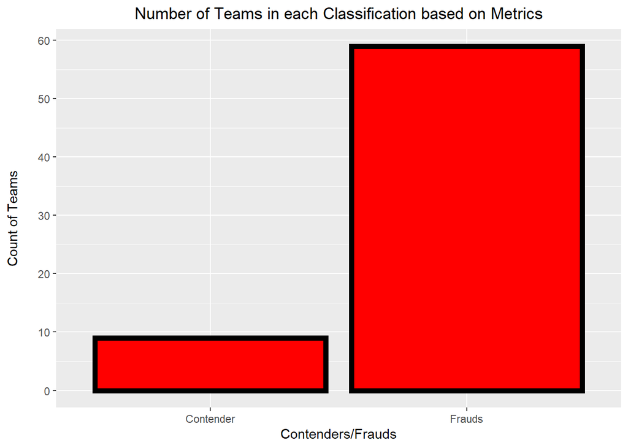

```r
mutated_bar <- ggplot(data = mutate_contender, (aes(x = Contender_Frauds)))
mutated_bar + geom_bar(color = "black", fill = "red", size = 2, bindwidth = 1) + labs(x = "Contenders/Frauds", y = "Count of Teams\n", title = "Number of Teams in each Classification based on Metrics") + theme(plot.title = element_text(hjust = 0.5)) + scale_y_continuous(breaks=c(0,10,20,30,40,50,60))
```

*bar plot of the number of tournament teams in each of the Power 6 conferences*

```r
num_teams <- teams %>%
  filter(p6_conference == "Y") %>%
  select(team_name, team_conference) %>%
  rename("Conference" = team_conference, "Team" = team_name)
```

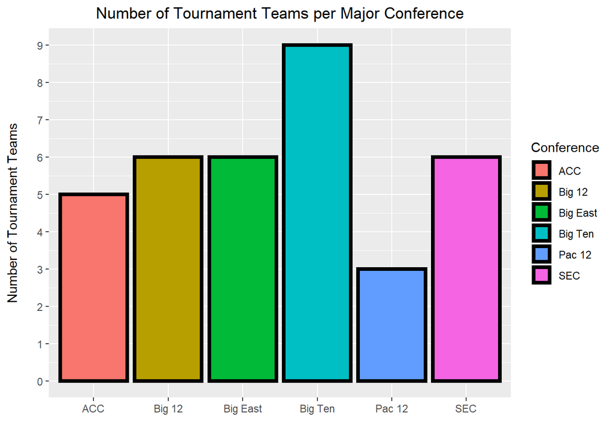

```r
p6_conferenceReps <- ggplot(data = num_teams, (aes(x = Conference, fill = Conference)))
p6_conferenceReps + geom_bar(color = "black", size = 1.5, bindwidth = 1.5) + labs(y = "Number of Tournament Teams\n", x = "", title = "Number of Tournament Teams per Major Conference") + theme(plot.title = element_text(hjust = 0.5)) + scale_y_continuous(breaks=c(0,1,2,3,4,5,6,7,8,9))
```

## 8.) Create a histogram for a numeric variable

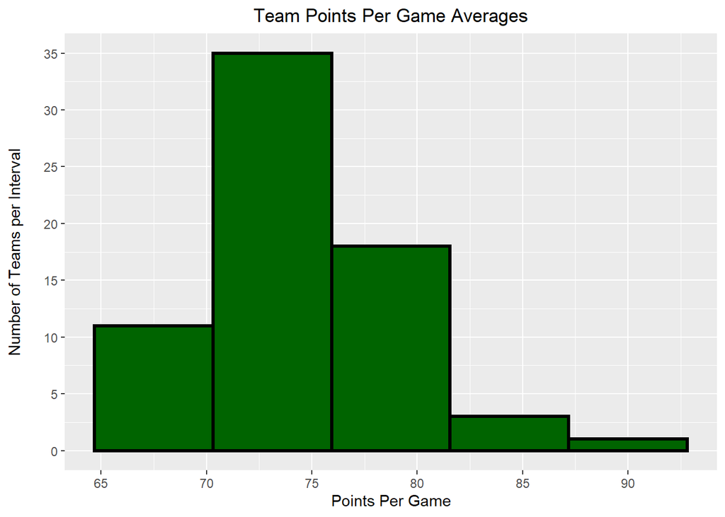

```r
teamPoints_histo <- ggplot(data = teams, (aes(x = team_ppg)))
teamPoints_histo + geom_histogram(color = "black", fill = "dark green", size = 1.2, bindwidth = 1, bins = 5) + labs(x = "Points Per Game", y = "Number of Teams per Interval\n", title = "Team Points Per Game Averages") + theme(plot.title = element_text(hjust = 0.5)) + scale_x_continuous(breaks=c(65,70,75,80,85,90)) + scale_y_continuous(breaks=c(0,5,10,15,20,25,30,35))
```

## 9.) Create an overlayed histogram for a numeric variable across one of the categorical variables

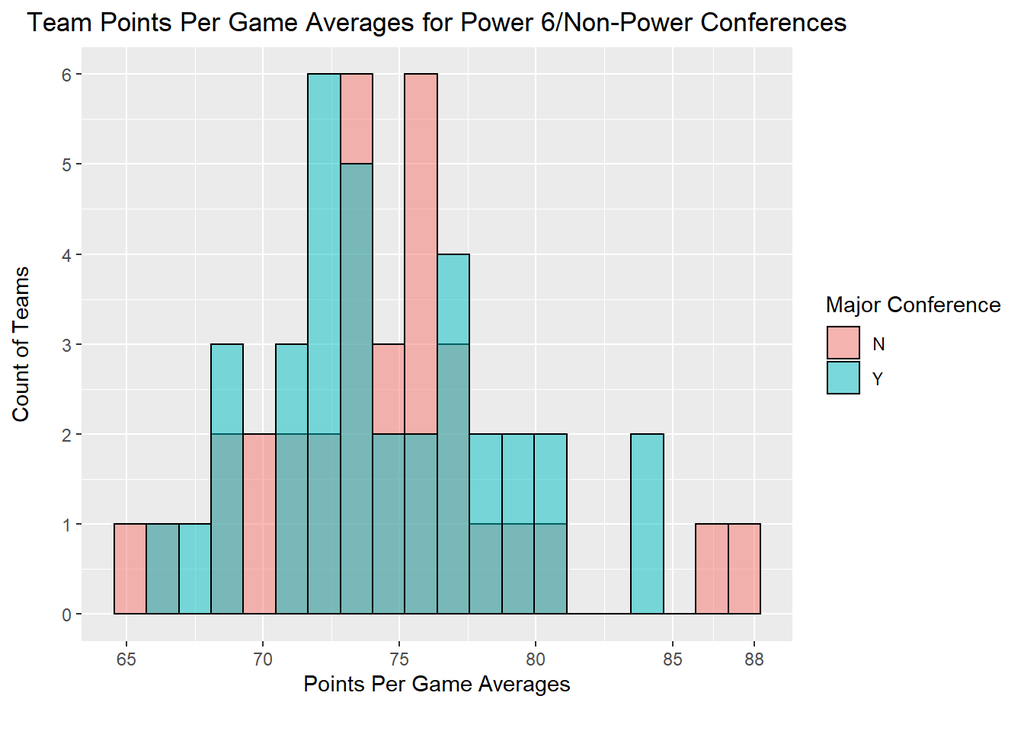

```r
ppg <- teams$team_ppg
p6 <- teams$p6_conference

overlay_histo <- ggplot(data = teams, (aes(x = ppg, fill = p6)))
overlay_histo + geom_histogram(position = "identity", alpha = 0.5, color="black", bins = 20) + labs(x = "Points Per Game Averages\n", y = "Count of Teams\n", title = "Team Points Per Game Averages for Power 6/Non-Power Conferences", fill = "Major Conference") + theme(plot.title = element_text(hjust = 0.5)) + scale_x_continuous(breaks=c(65,70,75,80,85,88)) + scale_y_continuous(breaks=c(0,1,2,3,4,5,6,7,8,9,10,11))
```

## 10.) Create a scatter plot relating two numeric variables including the least squares regression line

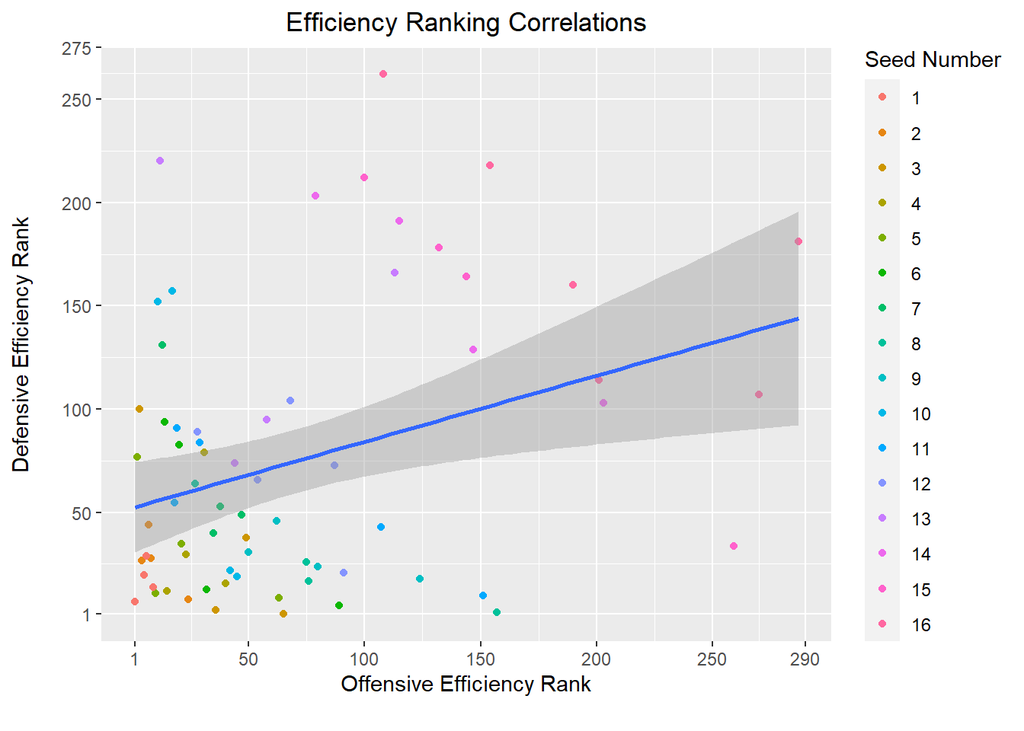

```r
scat_plot <- ggplot(data = teams, aes(x = off_efficiencyRank, y = def_efficiencyRank))
scat_plot + geom_point(aes(color = as.factor(tourney_seed))) + geom_smooth(method = "lm") + labs(x = "Offensive Efficiency Rank\n", y = "Defensive Efficiency Rank\n", title = "Efficiency Ranking Correlations", color = "Seed Number") + theme(plot.title = element_text(hjust = 0.5)) + scale_x_continuous(breaks=c(1,50,100,150,200,250,290)) + scale_y_continuous(breaks=c(1,50,100,150,200,250,275))
```

*Correlation Coefficient*

```r
cor_coeff <- cor(teams$off_efficiencyRank, teams$def_efficiencyRank)
cor_coeff
```

```
## [1] 0.3270888
```

```r
if (cor_coeff > 0) {
  print('The correlation between the offensive and defensive efficiencies of teams is positive')
} else {
  print('The correlation between the offensive and defensive efficiencies of teams is negative')
}
```

```
## [1] "The correlation between the offensive and defensive efficiencies of teams is positive"
```

## 11.) Use sckit learn to find the slope and y-intercept of the least squares regression line. Plot the line on the scatter plot.

```r
efficiency_model <- lm(off_efficiencyRank ~ def_efficiencyRank, data = teams)
efficiency_model
```

```
##
## Call:
## lm(formula = off_efficiencyRank ~ def_efficiencyRank, data = teams)
##
## Coefficients:
##        (Intercept)  def_efficiencyRank
##            44.7271              0.3351
```